# email_topic_classification

For a business unit operating from a shared Outlook inbox, managing a wide variety of emails covering a diverse range of topics was a complex task. The lack of visibility into the volume and frequency at which they were contacted about certain topics left them without a clear understanding of their email communication. This posed challenges in planning, resource allocation, and delivering training for other business units. Moreover, the emails they received could pertain to any number of different topics, further complicating the categorization process.

To tackle these challenges, an advanced email classifier was developed using a TensorFlow Neural Network, and Natural Language Processing (NLP) techinques. The solution goes beyond traditional single-topic predictions; it reads the content of each email, identifying multiple relevant topics associated with it. This capability empowers the business unit with data on the frequency of emails for each topic, considering their non-mutual exclusivity.

By leveraging the email classifier, the business unit can gain valuable insights into their email communication, and use them to make more informed and strategic decisions.

### Import Libraries, Initialize Variables, and Define Functions

```python
# Standard library imports
import glob
import os
import re
import string

# Third-party imports
import lime
import shap
import win32com.client
import matplotlib.pyplot as plt
import numpy as np
import pandas as pd
import pickle as pkl
from imblearn.over_sampling import SMOTE
from lime.lime_tabular import LimeTabularExplainer
from matplotlib.colors import Normalize
from matplotlib.ticker import MultipleLocator
from sklearn.feature_extraction.text import TfidfVectorizer
from sklearn.metrics import roc_curve, roc_auc_score
from sklearn.model_selection import StratifiedShuffleSplit
from tensorflow.keras.callbacks import ReduceLROnPlateau
from tensorflow.keras.layers import Dense, Dropout
from tensorflow.keras.models import Sequential
```

```python
# Define functions
def redact_dataframe(dataframe, columns_to_redact):
    """
    Redacts specified columns of a dataframe by replacing all alphanumeric characters with "x".
    Args:
        dataframe (pandas.DataFrame): The dataframe to be redacted.
        columns_to_redact (list): List of columns that are to be redacted.
    Returns:
        redacted_df (pandas.DataFrame): A copy of the inputted dataframe with all alphanumeric characters with "x".
    """
    redacted_df = dataframe.copy()

    # Iterate over each column to redact
    for column in columns_to_redact:
        # Check if the column exists in the DataFrame
        if column in redacted_df.columns.to_list():
            # Apply the redaction by replacing all characters in the column's values with 'x'
            redacted_df[column] = redacted_df[column].apply(lambda x: re.sub("[a-zA-Z0-9]", "x", str(x)))

    return redacted_df

def normalize_probabilities(softmax_array):
    """
    Takes in an nested array of softmax probabilities, where each topic_softmax in the parent array is an array of softmax
    probilities that sum to 1, and returns a nested array of normalized (min-max scaled) probabilities.
    Args:
        softmax_array (array): A nested array of probabilities
    Returns:
        norm_probs_list (list): A nested array of normalized probabilities
    """
    norm_probs_list = []

    # Iterate over each row's probability array
    for row_softmax in softmax_array:

        # Find the minimum and maximum probabilities in the current row's probability array
        row_min = min(row_softmax)
        row_max = max(row_softmax)

        row_norm_probs = [round((topic_softmax - row_min) / (row_max - row_min), 5) for topic_softmax in row_softmax]
        norm_probs_list.append(row_norm_probs)

    return norm_probs_list

def translate_encoded_labels_to_english(encoded_label_list, all_topics):
    """
    Translates list of encoded labels into a string containing English labels.
    Args:
        encoded_label_list (list): A list of lists containing binary encoded labels for each row of the data.
                                   Each inner list represents a row and contains 0s and 1s indicating the presence
                                   or absence of a label from all_topics.
        all_topics (list): A list of all possible labels (topics) in the dataset.
    Returns:
        english_labels_list (list): A list of strings containing English labels for each row of the data.
                                    Each string represents the English labels separated by commas for a specific row.
    """
    english_labels_list = []

    # Iterate over each row's encoded label list
    for row_encoded_label_list in encoded_label_list:
        row_english_labels = []

        # Convert binary encoded labels to their corresponding English labels
        for i in range(len(row_encoded_label_list)):
            # Check if the label is present (encoded as 1) in the current row
            if row_encoded_label_list[i] == 1:
                # Append the English label from all_topics to the row's English label list
                row_english_labels.append(all_topics[i])

        # Combine the row's English labels into a single string, separated by commas
        english_labels_list.append(", ".join(row_english_labels))

    return english_labels_list

def get_prediction_outcomes(actual_list, pred_list):
    """
    Calculate various prediction outcomes and metrics for a list of actual values and predicted values.
    Args:
        actual_list (list of lists): List containing the true labels for each data point.
        pred_list (list of lists): List containing the predicted labels for each data point.
    Returns:
        exact_match_list (list): List of boolean values indicating whether predictions match the actual values exactly.
        tp_list (list): List of integers representing true positives for each data point.
        fp_list (list): List of integers representing false positives for each data point.
        tn_list (list): List of integers representing true negatives for each data point.
        fn_list (list): List of integers representing false negatives for each data point.
    """
    exact_match_list = []
    tp_list = []
    fp_list = []
    tn_list = []
    fn_list = []

    # Iterate over each row in the data
    for row in range(len(actual_list)):
        row_actuals = actual_list[row]
        row_preds = pred_list[row]

        exact_match_list.append(sum([1 if row_actuals[i] != row_preds[i] else 0 for i in range(len(row_actuals))]) == 0)
        tp_list.append(sum([1 if row_actuals[i] == 1 and row_preds[i] == 1 else 0 for i in range(len(row_actuals))]))
        fp_list.append(sum([1 if row_actuals[i] == 0 and row_preds[i] == 1 else 0 for i in range(len(row_actuals))]))
        tn_list.append(sum([1 if row_actuals[i] == 0 and row_preds[i] == 0 else 0 for i in range(len(row_actuals))]))
        fn_list.append(sum([1 if row_actuals[i] == 1 and row_preds[i] == 0 else 0 for i in range(len(row_actuals))]))

    return exact_match_list, tp_list, fp_list, tn_list, fn_list
```

### Data Importation

The data to be imported consists of a collection of Outlook .msg email files that have been saved to a drive, and grouped by a subject matter expert based on the topic(s) that the email is about.  
The grouping was done by creating a sub-folder for each of the 28 disinct topics identified by the subject matter expert and placing a copy of the email into each sub-folder that is relevant to it.

[figure not shown]

As an email can be about mutiple topics, the same email can appear in multiple topic sub-folders.  
For example:

- email_1.msg is about topic 3 and topic 21, so a copy of it is in both sub-folders topic_03 and topic_21
- email_2.msg is about topic 14 only, so it is in sub-folder topic_14 only
- email_3.msg is about topics 5, 8, and 19 so a copy of it is in sub-folders topic_05, topic_08, and topic_19

*Note: in practice the topic labels are descriptive, however they contain potentially commercially-senstive information so they have been replaced with topic_01 to topic_28 for the purposes of demonstration.*

The emails are imported by:

1. Creating a list of distinct topics by using glob to get the names of all topic sub-folders
2. Interating through each sub-folder, then using win32com.client to iterate through each contained .msg file and store the email's subject and body in a list. The current topic sub-folder is also stored in a list
3. Creating a dataframe from the subject, body, and topic lists populated in step 2

```python
# Iterate througb sub-folders in the data directory and get list of distinct topics
email_directory = os.path.join(os.getcwd(), "Emails")
sub_directories = glob.glob(os.path.join(os.getcwd(), "Emails", "*"), recursive=True)
distinct_topics = [os.path.basename(sub_directory) for sub_directory in sub_directories]

# Display the distinct topics
print(distinct_topics)
```

```
['topic_01', 'topic_02', 'topic_03', 'topic_04', 'topic_05', 'topic_06', 'topic_07', 'topic_08', 'topic_09', 'topic_10', 'topic_11', 'topic_12', 'topic_13', 'topic_14', 'topic_15', 'topic_16', 'topic_17', 'topic_18', 'topic_19', 'topic_20', 'topic_21', 'topic_22', 'topic_23', 'topic_24', 'topic_25',…
```

```python
# Create empty lists for use in creating dataframe
subject_list = []
body_list = []
topic_list = []

# Create outlook object, then iterate through saved emails and save data
failures = 0
outlook = win32com.client.Dispatch("Outlook.Application").GetNamespace("MAPI")
for sub_directory in sub_directories:
    # Extract the topic from the sub_directory path
    topic = os.path.basename(sub_directory)

    # Get a list of email files in the sub_directory
    email_list = glob.glob(os.path.join(sub_directory, "*.msg"))
    for email in email_list:
        try:
            # Open the email using the outlook object
            msg = outlook.OpenSharedItem(email)

            # Initialize variables for storing subject, body, and email topic
            subject = ""
            body = ""
            email_topic = ""

            # Extract the subject, body, and email topic
            subject = str(msg.Subject)
            body = str(msg.Body)
            email_topic = topic

            # Append the extracted data to the respective lists
            subject_list.append(subject)
            body_list.append(body)
            topic_list.append(email_topic)

            # Delete the outlook object to release resources
            del msg

        except:
            # If there is an exception while processing an email, count it as a failure
            failures += 1
            print("{} email(s) could not be imported".format(failures), end="\r")

# Create dataframe
df_data = {"subject":subject_list, "body":body_list, "topic":topic_list}
email_df = pd.DataFrame(data=df_data)

# Display a redacted sample
redact_dataframe(email_df, ["subject", "body"]).sample(5)
```

|  | subject | body | topic |
| --- | --- | --- | --- |
| 2527 | xx: xxxx xxxxx xxxxxxx xxxxxxxxx - xxxxxx xxxx... | xxx xxxx 😊\r\n\r\nxx xxxxxx xxxx\r\n\r\nxxxx x... | topic_23 |
| 1785 | xxxx - xxxxx xxxxxxxxxxxx - xx xxxxx xxxx, xxx... | xx xxxx,\r\n\r\nxx: xxxx - xxxxx xxxxxxxxxxxx... | topic_15 |
| 1416 | xx: xxxxxx_+_xxxxx_xxxxxx_xxxxxxxxxx_xxx_xxxx"... | xxxx xxxxxxx xxxx,\r\n\r\nxx xxx xxx xxxxx xxx... | topic_09 |
| 681 | xxxx - xxx xxxxxxx | xxx xxxx 😊\r\n\r\nxxx x xxxxxx xxx xxxxxxxxxxx... | topic_05 |
| 2257 | xxxxx xxxx xxx xxxxx - xxxxxx \| xxx xxxxxx xx... | xxxxx xxxx,\r\n\r\nxxxxx-xxxx xxxxx xxxxxxxx: ... | topic_19 |

### Data Exploration

Several visualisations are created, to provide important context on the data:

**Plotting Distribution of Topics**  
First, the occurrence count for each unique email topic in the DataFrame is calculated. The most and least represented topics are determined, and the percentages of their occurrences is displayed. The purpose here is to understand the distribution of topics in the dataset and identify which topics are more prevalent and which are less common. A bar chart is then created to visually display the distribution, making it easier to interpret the results.

**Plotting Frequency of Multi-Topics**  
Next, the frequency of emails that have multiple topics, referred to as multi-topics, is assessed. The percentage of occurrences of emails with different counts of topics (e.g., single-topic, double-topic, triple-topic, etc.) is computed. The aim is to understand how often emails contain multiple topics and identify any patterns or trends related to the number of topics in emails. The resulting bar chart provides a visual representation of this information.

**Heatmap of Topic Co-occurrence**  
Next, a nested list to store the percentage of co-occurrence of each topic with other topics is constructed. It focuses on emails that have occurred more than once in the dataset and calculates the percentage of co-occurrence between each pair of topics. The goal is to identify patterns of topics that frequently co-occur in the same emails. It is them plotted as a heatmap, where each cell's color intensity indicates how frequently two topics appear together in the same emails. This visualization helps to identify which topics are commonly associated with each other and which pairs of topics have a stronger co-occurrence pattern. Grid lines and text annotations are added to enhance the readability and interpretability of the heatmap.

```
The most represented topic is topic_05, applies to 11.46% of all emails
The least represented topic is topic_27, applies to 0.66% of all emails
```

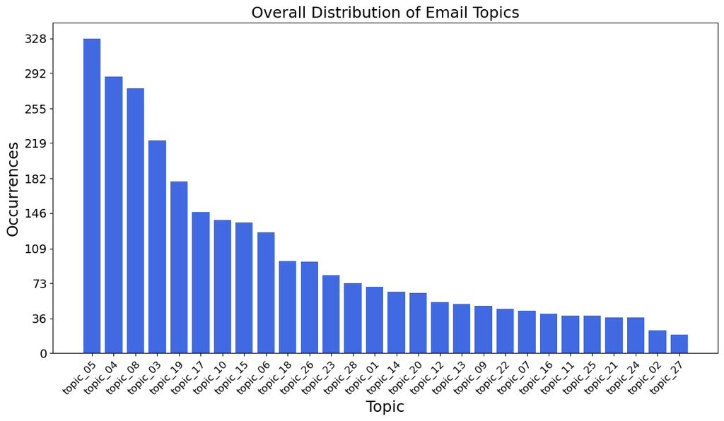

```python
# Plotting Distribution of Topics

# Extract the "topic" column from the DataFrame
plot_df = email_df["topic"]

# Count the occurrences of each topic and store them in value_counts
topic_value_counts = plot_df.value_counts()

# Get the list of topics and their respective counts
values = topic_value_counts.index.values.tolist()
counts = topic_value_counts.values.tolist()

# Calculate the percentage of the most and least represented topics
most_percent = round((counts[0] / email_df.shape[0]) * 100, 2)
least_percent = round((counts[-1] / email_df.shape[0]) * 100, 2)

# Print the statistics of the most and least represented topics
print(f"The most represented topic is {values[0]}, applies to {most_percent}% of all emails")
print(f"The least represented topic is {values[-1]}, applies to {least_percent}% of all emails")

# Create a bar plot to visualize the distribution of email topics
fig, ax = plt.subplots(figsize=(14, 7))
ax.bar(values, counts, color="royalblue")

# Set the title and labels for the plot
ax.set_title("Overall Distribution of Email Topics", fontsize=18)

x_ticks = np.arange(len(values))
ax.set_xticks(x_ticks)
ax.set_xticklabels(values, fontsize=12, rotation=45, ha="right", rotation_mode="anchor")

# Set custom y-axis ticks
y_ticks = [int(round(value, 0)) for value in np.linspace(0, max(counts), num=10)]
ax.set_yticks(y_ticks)
ax.set_yticklabels(y_ticks, fontsize=14)

plt.xlabel("Topic", fontsize=18)
plt.ylabel("Occurrences", fontsize=18)

# Display the plot
plt.show()
```

It's evident that there is a very unbalanced distribution of topics in the emails. This means that:

1. A stratified train-test split should be used
2. Synthetic oversampling might improve performance
3. A large batch size should be used when training
4. The percentage of the most and least represented labels (*topic_05* at 11.46% and *topic_27* at 0.66%) should be considered when defining the parameters of the TF-IDF Vectorizer

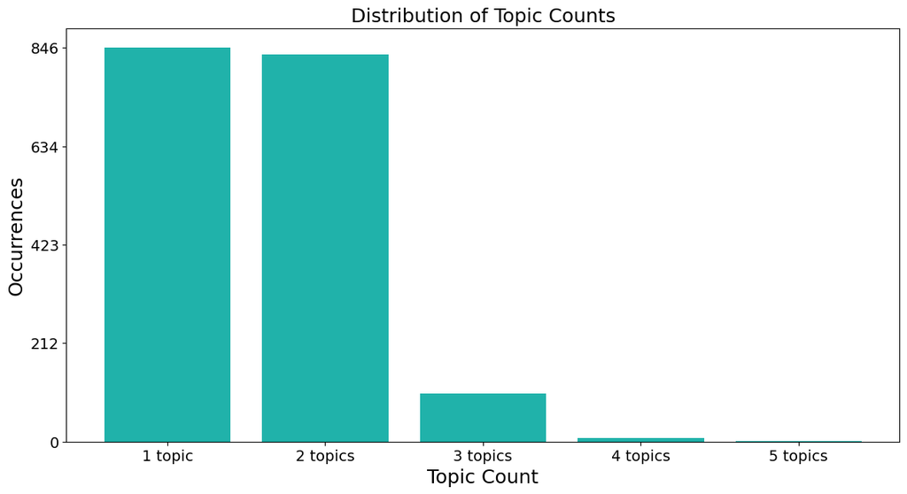

```python
# Plotting Frequency of Multi-Topics

# Calculate the number of occurrences of each email subject and store it in a new column
email_df["email_occurrences"] = email_df["subject"].map(email_df["subject"].value_counts())

# Plot frequency of multi-topics
# Extract the "email_occurrences" column from the DataFrame
plot_df = email_df["email_occurrences"]

# Count the occurrences of each unique topic count and sort them by index
occurence_value_counts = plot_df.value_counts().sort_index()

# Prepare values and counts for the plot
values = occurence_value_counts.index.values.tolist()
counts = occurence_value_counts.values.tolist()

# Calculate the average number of occurrences for each topic count
for i in range(len(occurence_value_counts)):
    counts[i] = counts[i] / values[i]
    # Modify the value label to include the word "topic(s)" with proper pluralization
    values[i] = str(values[i]) + " topic" + ("s" if values[i] != 1 else "")

# Create a bar plot to visualize the distribution of topic counts
fig, ax = plt.subplots(figsize=(14, 7))
ax.bar(values, counts, color="lightseagreen")

# Set the title and labels for the plot
ax.set_title("Distribution of Topic Counts", fontsize=18)

x_ticks = np.arange(len(values))
ax.set_xticks(np.arange(len(values)))
ax.set_xticklabels(values, fontsize=14)

# Set custom y-axis ticks
y_ticks = [int(round(value, 0)) for value in np.linspace(0, max(counts), num=5)]
ax.set_yticks(y_ticks)
ax.set_yticklabels(y_ticks, fontsize=14)

plt.xlabel("Topic Count", fontsize=18)
plt.ylabel("Occurrences", fontsize=18)

# Display the plot
plt.show()
```

It's more common than not for emails to be about multiple topics. This means the model needs to be able to predict multiple labels for a single email, independent of one another.  
E.g. if an email is about topic_3 *and* topic_21, the model needs to be able to apply two distinct labels rather than a single label representing both: “topic_3”, and “topic_21”; not “topic_3, topic_21”

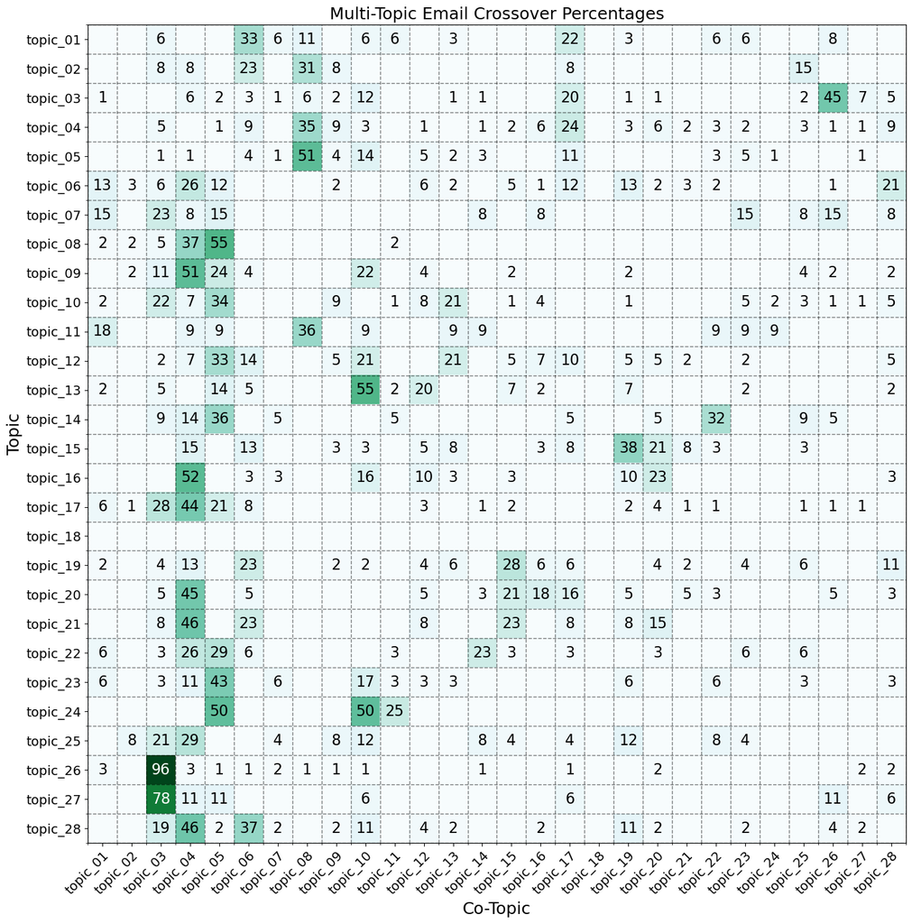

```python
# Heatmap of Topic Co-occurrence

# Create a new dataframe that only contains emails that have occurred more than once in the original dataframe
multi_df = email_df[email_df["email_occurrences"] > 1]

plot_list = [] # Will contain nested lists with the percentage of co-occurrence of each topic with other topics
highest_cooccurrence = 0 # Will store the highest count of co-occurrence found

# Loop through each distinct topic in the DataFrame
for topic_1 in distinct_topics:

    # Create a new dataframe that contains only the emails that belong to the current topic
    df_1 = multi_df[multi_df["topic"] == topic_1]

    topic_occurrence = max(df_1.shape[0], 1) # max() is used to avoid division by zero errors
    subjects_list = df_1["subject"].to_list() # For later use in isin() function
    sub_list = [] # Store the percentage of co-occurrence of the current topic with other topics; nested in plot_list

    # Loop through each distinct topic again for comparison
    for topic_2 in distinct_topics:

        if topic_1 != topic_2: # Topic co-occurrence with itself isn't to be plotted

            # Create a new dataframe that contains only the emails that belong to the current inner loop topic
            df_2 = multi_df[multi_df["topic"] == topic_2]

            count = sum(df_2["subject"].isin(subjects_list))
            append_value = int(round((count / topic_occurrence) * 100, 0))
            sub_list.append(append_value)
            highest_cooccurrence = max(highest_cooccurrence, count)
        else:
            sub_list.append(0)
    plot_list.append(sub_list)

# Drop email_occurrences column
email_df.drop(columns=["email_occurrences"], inplace=True)

### Plot a heatmap using the nested list of topic co-occurrence
fig, ax = plt.subplots(figsize=(14, 14))
im = ax.imshow(plot_list, cmap="BuGn")

ax.set_title("Multi-Topic Email Crossover Percentages", fontsize=18)

plt.xlabel("Co-Topic", fontsize=18)
ax.set_xticks(np.arange(len(distinct_topics)))
ax.set_xticklabels(distinct_topics, fontsize=14, rotation=45, ha="right", rotation_mode="anchor")

plt.ylabel("Topic", fontsize=18)
ax.set_yticks(np.arange(len(distinct_topics)))
ax.set_yticklabels(distinct_topics, fontsize=14)

ax.xaxis.set_minor_locator(MultipleLocator(0.5))
ax.yaxis.set_minor_locator(MultipleLocator(0.5))
ax.grid(which="minor", color="k", linestyle="dashed", linewidth=1, alpha=0.5)

# Add text labels with co-occurrence percentages to the heatmap
for i in range(len(distinct_topics)):
    for j in range(len(distinct_topics)):
        count = plot_list[i][j]
        c = "w" if count > (highest_cooccurrence / 2) else "k" # Set label color based on count value
        if count > 0:
            text = ax.text(j, i, count, ha="center", va="center", color=c, fontsize=16)

fig.tight_layout()
plt.show()
```

Most combinations of labels aren't represented in the data, which means the model could perform better if trained to recognize individual labels. By doing so, when making predictions, the model can identify labels independently, even for combinations that were not present in its training data. This could allow the model to predict combinations that were not observed during training.

A very high 96% of all emails about *topic_26* are also about *topic_03*, but only 45% of all emails about *topic_03* are also about *topic_26*. This suggests that *topic_26* could be considered a sub-topic of *topic_03*, and including it separately might be superflous. It was left as a separate topic in the model, but removing it in future iterations could be considered.

### Text Cleaning and Tokenization

Tokenization is an important step in NLP because it breaks down text into smaller units called tokens, which in this case are individual words, enabling a machine learning algorithm to understand and process it. By tokenizing the text, NLP models can convert unstructured text data into a structured format, allowing them to learn to perform the task of classification. Tokenization helps in reducing the complexity of the language and aids in extracting meaningful information from the text, which can be further analyzed and processed efficiently.

Here, tokenization is performed by going through each word in the subject and body of the emails, removing any punctuation, then passing them through a variety of functions to filter out any that:

1. Are in a pre-defined set of "stopwords": words that provide no explanatory value such as salutations, names, conjunctions etc.  
   Two sets of stopwords are used: the first is the set of general English stopwords used in MySQL; and the second is a set of stopwords specific to the organization for which this project is being done, it contains things like names of individuals and business units, organization-specific jargon etc.
2. Are the names of attachments, or are urls in the email body.
3. Are a single character in length, or are more than 15 characters in length.
4. Contain a numerical character, and aren't in a pre-defined set of words to be kept. This set of allowed words with numerical characters has a small number of organization-specific terms that are likely to provide explanatory value in classification.

```python
### Define tokenization exception functions (functions that identify words that should not be included as tokens)

# Stop words
with open(os.path.join(os.getcwd(), "stopwords_general.txt"), "r") as text_file:
    general_stop_words = text_file.read().replace("'", "").replace("\n", "").split(",")
with open(os.path.join(os.getcwd(), "stopwords_specific.txt"), "r") as text_file:
    specific_stop_words = text_file.read().replace("'", "").replace("\n", "").split(",")
def is_stopword(word):
    """
    Takes in a word and returns a boolean value indicating whether the word is a stopword or not.
    The check is performed by comparing the lowercase version of the word against a predefined list of general stopwords
    and a predefined list of specific stopwords.
    Args:
        word (str): The word to check.
    Returns:
        boolean: Whether or not the word is a stopword.
    """
    return (word.lower() in general_stop_words or
            word.lower() in specific_stop_words)

# Attachment names and urls
suffixes = ["png", "jpg", "jpeg", "pdf", "gif", "com", "conz", "comau", "org"]
def is_attachment_or_url(word):
    """
    Takes in a word and returns a boolean value indicating whether the word is an attachment or a url.
    The check is performed by comparing the lowercase version of the suffix of the word of 3, 4 or 5 characters against
    a predefined list of suffixes.
    Args:
        word (str): The word to check.
    Returns:
        boolean: Whether or not the word is an attachment name or url.
    """
    return (word.lower()[-3:] in suffixes or
            word.lower()[-4:] in suffixes or
            word.lower()[-5:] in suffixes)

# Is wrong length
def is_wrong_length(word):
    """
    Takes in a word and returns a boolean value indicating whether the word is less than 2 or
    more than 15 characters long.
    Args:
        word (str): The word to check.
    Returns:
        boolean: Whether or not the word is a unallowed length.
    """
    return (len(word) < 2 or len(word) > 15)

# Contains numbers
text_file = open(os.path.join(os.getcwd(), "allowed_numericals.txt"), "r")
allowed_numericals = text_file.read().replace("'", "").replace("\n", "").split(",")
def contains_numbers(word):
    """
    Takes in a word and returns a boolean value indicating whether the word contains numbers.
    The check is performed by using a regular expression to search for any digits (0-9) in the lowercase version of the
    word and also checking if the word is not present in a predefined list of allowed words with numerical characters.
    Args:
        word (str): The word to check.
    Returns:
        boolean: Whether or not the word contains numerical characters and is not in the allowed list.
    """
    return re.search("[0-9]", word.lower()) and word.lower() not in allowed_numericals

# Inclusion function
def include_word(word):
    """
    Takes in a word and returns a boolean value indicating whether the word should be included as a
    token.
    The check is performed by inputting the word in the is_stopword(), is_attachment_or_url(), is_wrong_length(),
    and contains_numbers() functions.
    Args:
        word (str): The word to check.
    Returns:
        boolean: Whether or not the word should be included as a token.
    """
    return not (is_stopword(word) or
                is_attachment_or_url(word) or
                is_wrong_length(word) or
                contains_numbers(word))

# Tokensizer
def tokenize(sentence):
    """
    Tokenizes a given sentence by removing any newline characters, tabs, and punctuations, then splitting the sentence
    into a list of words.
    Filters out any words that are not included by the include_word() function.
    The final list of filtered and stemmed tokens is returned.
    Args:
        sentence (str): The sentence to be tokenized.
    Returns:
        list: The list of tokens representing the sentence.
    """
    sentence = re.sub("\\t|\\n|\\r|\t|\n|\r", " ", str(sentence))
    sentence = sentence.translate(str.maketrans('', '', string.punctuation))
    word_list = sentence.split(" ")
    include_tokens = []
    for word in word_list:
        if include_word(word):
            include_tokens.append(word.lower())

    return include_tokens
```

```python
# Tokenize
email_df["tokens"] = email_df["subject"].apply(lambda x : tokenize(x)) + email_df["body"].apply(lambda x : tokenize(x))

# Display a redacted sample
redact_dataframe(email_df, ["subject", "body", "tokens"]).sample(5)
```

|  | subject | body | topic | tokens |
| --- | --- | --- | --- | --- |
| 2155 | xxxxxxx xxxx - xxxxxxxx xxxx xxxxx - xx xxxxxx... | \r\n\r\n_____________________________________... | topic_18 | ['xxxxxxx', 'xxxx', 'xxxxxxxx', 'xx', 'xxxxxxx... |
| 1746 | xxx xxxxxxx xxxxxxxx? x & x xxxxx \| xxx-xxxxx | xx xxxx\r\n\r\nxxxxx xxxxxxxx – xxx xx xxxxx x... | topic_14 | ['xxxxxxx', 'xxxxxxxx', 'xxxxx', 'xxxxx', 'xxx... |
| 1588 | xx: xx xxxxxxxxxx xxx xxxxxxxxxxxx xxx xxxxxxx... | xxx xx xxx xx 😊\r\n\r\nxxx xxxxx xxx!\r\n\r\n\... | topic_11 | ['xx', 'xxx', 'xxx', 'xxxxxxx', 'xxxxxx', 'xxx... |
| 798 | xxxxxxxxxx \| xxx: xxxxxxxxxx \| xxx: xxxxxxx xx... | \r\n\r\n \r\n\r\n \r\n\r\nxxxxxxx xxxx: xxxxxx... | topic_05 | ['xxx', 'xxx', 'xxxxxxx', 'xxxxxxxxxxxxx', 'xx... |
| 2531 | xx: xxxxxxxxxx x xxxxx xxxxxxxx xxx xxxxxxx. | \r\n\r\nxxxx: xxxxxxx, xxxxxx <xxxxxx_xxxxxxx@... | topic_23 | ['xxxxx', 'xxxxxxxx', 'xxx', 'xxxxxxx', 'xxxxx... |

### Encoding

Encoding is the process of converting text into a numerical represenation that can be understood by a machine learning model. Both the topics, and the subject/body tokens created above are encoded.

**Topics**  
The email topics are encoded simply by creating a 28-length array of 1s and 0s. A 1 in the n-th position (zero-indexed) in the array indicates that topic_(n+1) applies to the email. For example:  
[0, 0, 0, 1, 0, 0, 0, 0, 0, 0, 0, 0, 0, 0, 0, 0, 0, 0, 0, 0, 0, 0, 0, 0, 0, 0, 0, 0] has a 1 in the 3rd position, so topic_4 applies.  
[1, 0, 0, 0, 0, 0, 1, 0, 0, 0, 0, 0, 0, 0, 0, 0, 0, 0, 0, 0, 1, 0, 0, 0, 0, 0, 0, 0] has 1s in the 0th, 6th, and 20th positions, so topic_1, topic_7, and topic_21 apply.

Encodings are created on both a row level (representing the topic against the row only), and then on email level (representing all topics against the email in the row).

**Tokens**  
The tokens are encoded by creating a TF-IDF representation. TF-IDF is a statistical measure that evaluates the importance of a token within an email, relative to the whole collection of emails. Each email will be represented by a 3689-length array, where each element represents how often a token or pair of tokens appears in the email, relative to how often it appears in every email.  
Single words, and word pairs that appeared in at least 0.25% and less than 50% of all emails were included.

```python
# Encode topic and get email-level values

# Encode row topic
encoded_df = pd.get_dummies(email_df["topic"], dtype="int16")
email_df["row_topic_encoded"] = encoded_df.values.tolist()

# Encode email (merged) topics
topic_dictionary = {}
encoded_dictionary = {}
for subject in set(email_df["subject"].to_list()):
    sub_df = email_df[email_df["subject"] == subject]
    topic_list = sub_df["topic"].to_list()
    encoded_list = sub_df["row_topic_encoded"].to_list()
    topic_dictionary[subject] = ", ".join(sorted(topic_list))
    encoded_dictionary[subject] = [sum(zipped) for zipped in zip(*encoded_list)]
email_df["email_topic"] = email_df["subject"].map(topic_dictionary)
email_df["email_topic_encoded"] = email_df["subject"].map(encoded_dictionary)

# Tidy columns
email_df.rename(columns = {"topic":"row_topic"}, inplace = True)
email_df = email_df[["subject", "body", "tokens", "row_topic", "row_topic_encoded", "email_topic", "email_topic_encoded"]]

# Display a redacted sample
redact_dataframe(email_df, ["subject", "body", "tokens"]).sample(5)
```

|  | subject | body | tokens | row_topic | row_topic_encoded | email_topic | email_topic_encoded |
| --- | --- | --- | --- | --- | --- | --- | --- |
| 1294 | xxx xx: xxxx xxx xxxx xx-xx-xxxx - xxx xxxxxxx... | xx xxxx,\r\n\r\nxx xxxx x xxxxxxxxx xxxxxxxxxx... | ['xxx', 'xxxx', 'xxx', 'xxxx', 'xxx', 'xxxxxxx... | topic_08 | [0, 0, 0, 0, 0, 0, 0, 1, 0, 0, 0, 0, 0, 0, 0, ... | topic_04, topic_08 | [0, 0, 0, 1, 0, 0, 0, 1, 0, 0, 0, 0, 0, 0, 0, ... |
| 1377 | xxxxxxx \| xxxxxxxxxx \| xxxx xx xxxxxxxxxxx xxx... | [xxx xxxxxx xxxxxx - xxxxxxxxx xxxxxxxx x]\r\n... | ['xxxx', 'xx', 'xxxxxxxxxxx', 'xxxxxxxxxxxxx',... | topic_09 | [0, 0, 0, 0, 0, 0, 0, 0, 1, 0, 0, 0, 0, 0, 0, ... | topic_03, topic_09, topic_10 | [0, 0, 1, 0, 0, 0, 0, 0, 1, 1, 0, 0, 0, 0, 0, ... |
| 1651 | xxxxxxxx xxxxx xxxxx | xx xxxx,\r\n\r\nxxxxxx xx xxxxxxxxxx xxxxx xxx... | ['xxxxxxxx', 'xxxxx', 'xxxxx', 'xxxxxx', 'xxxx... | topic_12 | [0, 0, 0, 0, 0, 0, 0, 0, 0, 0, 0, 1, 0, 0, 0, ... | topic_12 | [0, 0, 0, 0, 0, 0, 0, 0, 0, 0, 0, 1, 0, 0, 0, ... |
| 793 | xxxxxxxxxx \| xxxxxxxxxxxx \| xxxxx xxxxx xxxxxx... | xx xxxxx,\r\n\r\nxx: xxxxxxxxxx \| xxxxxxxxxxx... | ['xxxxx', 'xxxxx', 'xxxxxx', 'xxxxxxxxxxxxx', ... | topic_05 | [0, 0, 0, 0, 1, 0, 0, 0, 0, 0, 0, 0, 0, 0, 0, ... | topic_05, topic_10, topic_13 | [0, 0, 0, 0, 1, 0, 0, 0, 0, 1, 0, 0, 1, 0, 0, ... |
| 959 | xxxxx xxxx xxxxxxxx: xxxxxx - xxx xxxxx xxx xx... | xx xxxx,\r\n\r\nxx: xxxxx xxxx xxxxxxxx: xxxx... | ['xxxxx', 'xxxx', 'xxxxxxxx', 'xxxxx', 'xxx', ... | topic_06 | [0, 0, 0, 0, 0, 1, 0, 0, 0, 0, 0, 0, 0, 0, 0, ... | topic_04, topic_06, topic_12, topic_15, topic_17 | [0, 0, 0, 1, 0, 1, 0, 0, 0, 0, 0, 1, 0, 0, 1, ... |

```python
# Create tfidf_matrix
list_of_strings = email_df["tokens"].apply(lambda x : " ".join(x)).to_list()

tfidf_vectorizer = TfidfVectorizer(max_df=0.5, min_df=0.0025, use_idf=True, ngram_range=(1, 2))
tfidf_matrix = tfidf_vectorizer.fit_transform(list_of_strings)
print(f"There are {tfidf_matrix.shape[1]} total tokens in the TF-IDF matrix")

# Output tfidf_vectorizer for use with future data
with open(os.path.join(os.getcwd(), "email_tfidf_vectorizer.pkl"), "wb") as file:
    pkl.dump(tfidf_vectorizer, file)

# Add tfidf_matrix to dataframe
email_df["tfidf_matrix"] = list(tfidf_matrix.toarray(order="C"))

redact_dataframe(email_df, ["subject", "body", "tokens"]).sample(5)
```

```
There are 3689 total tokens in the TF-IDF matrix
```

|  | subject | body | tokens | row_topic | row_topic_encoded | email_topic | email_topic_encoded | tfidf_matrix |
| --- | --- | --- | --- | --- | --- | --- | --- | --- |
| 129 | xx: xxx xxxxxxx - xxxxxxxx xx xxxxxxx xx xxxxx... | xxx xxxx,\r\n\r\nx xx xxxxxxxx xx xxxxxxx xx x... | ['xxxxxxxx', 'xxxxxxx', 'xxxxxx', 'xxxxx', 'xx... | topic_03 | [0, 0, 1, 0, 0, 0, 0, 0, 0, 0, 0, 0, 0, 0, 0, ... | topic_03, topic_26 | [0, 0, 1, 0, 0, 0, 0, 0, 0, 0, 0, 0, 0, 0, 0, ... | [0.0, 0.0, 0.21154280615408214, 0.211542806154... |
| 56 | xx: xxx - xxxxxx xxx xxxxxxx xxxxxxx | xx xxxxxx, \r\n\r\n \r\n\r\nxxxxxx xxxx xxxx x... | ['xxxxxx', 'xxx', 'xxxxxxx', 'xx', 'xxxxxxxx',... | topic_01 | [1, 0, 0, 0, 0, 0, 0, 0, 0, 0, 0, 0, 0, 0, 0, ... | topic_01, topic_17 | [1, 0, 0, 0, 0, 0, 0, 0, 0, 0, 0, 0, 0, 0, 0, ... | [0.0, 0.12734537058983905, 0.0, 0.0, 0.0, 0.0,... |
| 2517 | xxxxxx xxxxxxxx - xxxxxxxxxx xxx xxxxxxxxxx | xxxx xxxxxxxxx xxxx. \r\n\r\n \r\n\r\nxxx xx x... | ['xxxxxx', 'xxxxxxxx', 'xxxx', 'xxxxxxxxx', 'x... | topic_23 | [0, 0, 0, 0, 0, 0, 0, 0, 0, 0, 0, 0, 0, 0, 0, ... | topic_23 | [0, 0, 0, 0, 0, 0, 0, 0, 0, 0, 0, 0, 0, 0, 0, ... | [0.0, 0.0, 0.0, 0.0, 0.03967994005724906, 0.03... |
| 2561 | xx: xxx xxxxxxx - xxxxx xxx xxxxxxxxxx | xxxx xxxxxxxxx,\r\n\r\nxxxx xxx xxxx xxxxxxxx,... | ['xxxxx', 'xxxxxxxxxx', 'xxxx', 'xxxxxxxxx', '... | topic_23 | [0, 0, 0, 0, 0, 0, 0, 0, 0, 0, 0, 0, 0, 0, 0, ... | topic_23, topic_28 | [0, 0, 0, 0, 0, 0, 0, 0, 0, 0, 0, 0, 0, 0, 0, ... | [0.0, 0.0, 0.0, 0.0, 0.0, 0.0, 0.0, 0.0, 0.0, ... |
| 13 | xx: xxxxx xxxxxxxx: xxxxxxxxxxxx | xx xxxx,\r\n\r\n \r\n\r\nxxx xx xxxxxx xxxx xx... | ['xxxxx', 'xxxxxxxx', 'xxxxxx', 'xx', 'xxxxx',... | topic_01 | [1, 0, 0, 0, 0, 0, 0, 0, 0, 0, 0, 0, 0, 0, 0, ... | topic_01, topic_22 | [1, 0, 0, 0, 0, 0, 0, 0, 0, 0, 0, 0, 0, 0, 0, ... | [0.0, 0.0, 0.0, 0.0, 0.05803700379438454, 0.05... |

### Data splitting, and augmentation

A stratified shuffle is employed to divide the data into training and testing sets, ensuring that an even as possible distribution of topics is present within both sets. Using a purely random split would introduce a risk that all instances of a topic that occurs very rarely could be included in one set and not the other. This would mean that either the topic isn't included in the training data and so the model couldn't learn to recognise it, or that it wisn't included in the testing data so the model's ability to recognise it can't be validated.

Due to the very unbalanced distribution of topics, the data was augmented using a method called Synthetic Minority Over-sampling Technique (SMOTE).  
SMOTE works by creating synthetic examples of the minority topics, essentially generating new training instances that closely resemble existing ones. his artificial augmentation of the training data levels the playing field by ensuring that each topic has a comparable number of training instances. As a result, the email analysis system becomes well-equipped to handle any topic it encounters, regardless of its frequency in real-world emails. This process enhances the system's ability to accurately classify emails and provides a more balanced and reliable performance across the board. SMOTE requires at least 3 occurences in the data to create sythetic examples from, so any topics that appeared less than 3 times in train_df were duplicated.

Finally, the train and test sets were split into X and y sets, where the X sets contain the tf-idf matrices to be fed into the model, and the y sets contain the target encoded labels that the model will be trained to output.

```python
# Create the train and test split dataframe
sss = StratifiedShuffleSplit(n_splits=1, test_size=0.33, random_state=123)

# Define the features (X) and the target variable (y)
X = email_df
y = email_df["row_topic"]

# Perform stratified shuffle split to create training and testing sets
for train_index, test_index in sss.split(X, y):
    # Create train and test dataframes based on the split indices
    train_df = email_df.filter(items=train_index, axis=0)
    test_df = email_df.filter(items=test_index, axis=0)

# Reset the index of the train and test dataframes
train_df.reset_index(inplace=True, drop=False)
test_df.reset_index(inplace=True, drop=False)

# Duplicate rows in the train dataframe to allow n_neighbours smote
smote_neighbours = 3
for i in range(smote_neighbours):
    # Calculate how often each topic occurs in training set
    train_df["email_topic_frequency"] = train_df["email_topic"].map(train_df["email_topic"].value_counts())

    # Create copy of train_df and filter to include only those topics that occur i+1 times
    under_min_df = train_df.copy()
    under_min_df = under_min_df[under_min_df["email_topic_frequency"] == i + 1]

    # Remove duplicates from under_min_df and concat to train_df (duplicating in train_df topics that appear <3 times)
    under_min_df.drop_duplicates(subset=["subject"], keep="first", inplace=True)
    train_df = pd.concat([train_df, under_min_df], axis=0)
    train_df.reset_index(inplace=True, drop=True)

# Re-calculate how often each topic occurs in training set
train_df["email_topic_frequency"] = train_df["email_topic"].map(train_df["email_topic"].value_counts())
```

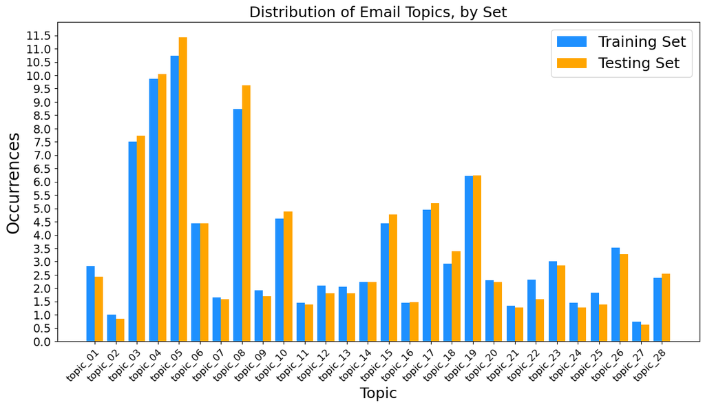

```python
# Plot distribution of topics in each set

# Calculate what percentage of the total each topic makes up
train_percentages = []
test_percentages = []
train_value_counts = train_df["row_topic"].value_counts()
test_value_counts = test_df["row_topic"].value_counts()
for topic in distinct_topics:

    if topic in train_value_counts:
        train_percentages.append(train_value_counts[topic])
    else:
        train_percentages.append(0)

    if topic in test_value_counts:
        test_percentages.append(test_value_counts[topic])
    else:
        test_percentages.append(0)

train_percentages = np.around(train_percentages / sum(train_percentages) * 100, 2).tolist()
test_percentages = np.around(test_percentages / sum(test_percentages) * 100, 2).tolist()

# Create x_ticks and y_ticks arrays
x_ticks = np.arange(len(distinct_topics))
y_ticks = np.arange(0, max(train_percentages + test_percentages) + 0.5, 0.5)

# Create a bar plot to visualize the distribution of email topics
fig, ax = plt.subplots(figsize=(14, 7))

bar_width = 0.4
ax.bar(x_ticks - bar_width/2, train_percentages, bar_width, label="Training Set", color="dodgerblue")
ax.bar(x_ticks + bar_width/2, test_percentages, bar_width, label="Testing Set", color="orange")

# Set the title and labels for the plot
ax.set_title("Distribution of Email Topics, by Set", fontsize=18)

# Ticks
ax.set_xticks(x_ticks)
ax.set_xticklabels(distinct_topics, fontsize=12, rotation=45, ha="right", rotation_mode="anchor")

ax.set_yticks(y_ticks)
ax.set_yticklabels(y_ticks, fontsize=14)

# Axis labels
plt.xlabel("Topic", fontsize=18)
plt.ylabel("Occurrences", fontsize=20)

# Legend
ax.legend(fontsize=18)

# Display the plot
plt.show()
```

```python
# SMOTE
oversample = SMOTE(k_neighbors = smote_neighbours)
X_smote, y_smote = oversample.fit_resample(train_df["tfidf_matrix"].to_list(), train_df["email_topic"].to_list())

# Split the email level entries outputted by smote into row level encodings
X_train = []
y_train = []
for i in range(len(y_smote)):
    for topic in distinct_topics:
        if y_smote[i].find(topic) != -1:
            X_train.append(X_smote[i])
            y_train.append([1 if value == topic else 0 for value in distinct_topics])

X_train = pd.DataFrame(data={"X_train":X_train})
y_train = pd.DataFrame(data={"y_train":y_train})
X_test = pd.DataFrame(data={"X_test":[list(array) for array in test_df["tfidf_matrix"].to_list()]})
y_test = pd.DataFrame(data={"y_test":[list(array) for array in test_df["email_topic_encoded"].to_list()]})
subjects_train = train_df["subject"].to_list()
subjects_test = test_df["subject"].to_list()

X_train = np.stack(X_train["X_train"].to_list())
y_train = np.stack(y_train["y_train"].to_list())
X_test = np.stack(X_test["X_test"].to_list())
y_test = np.stack(y_test["y_test"].to_list())
```

### Define, Train, and Save the Model

```python
# Define and fit model
input_size = X_train[0].size
output_size = y_train[0].size

# Wide
model = Sequential(name="email_topic_classifier")
model.add(Dense(input_size, input_shape=(input_size,), activation="swish"))
model.add(Dropout(0.2))
model.add(Dense((input_size + output_size) / 2, activation="swish"))
model.add(Dropout(0.2))
model.add(Dense(output_size, activation="softmax"))

model_callbacks = [ReduceLROnPlateau(monitor="loss", factor=0.5, patience=5, verbose=0, min_lr=0.0001)]
model.compile(loss="poisson", optimizer="adam", metrics=["accuracy", "Precision", "Recall"])

fitted_model = model.fit(X_train, y_train, epochs=100, batch_size=1024, verbose=0, callbacks=model_callbacks)

# Save model
model.save(os.path.join(os.getcwd(), "email_topic_classifier"))

# Display model summary
model.summary()
```

```
Model: "email_topic_classifier"
_________________________________________________________________
 Layer (type)                Output Shape              Param #
=================================================================
 dense_15 (Dense)            (None, 3689)              13612410

 dropout_10 (Dropout)        (None, 3689)              0

 dense_16 (Dense)            (None, 1858)              6856020

 dropout_11 (Dropout)        (None, 1858)              0

 dense_17 (Dense)            (None, 28)                52052

=================================================================
Total params: 20,520,482
Trainable params: 20,520,482
Non-trainable params: 0
_________________________________________________________________
```

### Performance Evaluation

The model's performance is evaluated in terms of the 4 prediction outcomes (true positive, true negative, false positive, or false negative); and precision, recall, F1 score, and accuracy metrics. As the distribtion of topics is so unbalanced, the F1 score (which harmonizes precision and recall, offering a balanced evaluation of the model's overall classification prowess) provides the most value as a measure of the model's performance.

The model generates probabilistic predictions using a softmax function, which produces an array indicating the likelihood that each label should be assigned to the email. These probabilities are adjusted to ensure they add up to 1. Since the goal is to accommodate the prediction of multiple topics, the softmax probabilities undergo a normalization process. This normalization scales the highest probability to 1 and the lowest probability to 0, effectively stretching or compressing all other probabilities proportionally between these two extremes.

```python
# Predict on test set
probs = model.predict(X_test) # Output softmax probabilities from model
norm_preds = normalize_probabilities(probs) # Normlize softmax probabilities
preds = [[round(element) for element in sublist] for sublist in norm_preds]  # Predict topics from normalized probabilities
actual_english = translate_encoded_labels_to_english(y_test, distinct_topics) # Translate actual labels to english string
predicted_english = translate_encoded_labels_to_english(preds, distinct_topics) # Translate predicted labels to english string
exact, tp, fp, tn, fn = get_prediction_outcomes(list(y_test), preds) # Calculate prediction outcome lists

# Calculat metrics from prediction outcome lists
total = len(preds)
accuracy = round((sum(exact) / total) * 100, 2)
precision = round((sum(tp) / (sum(tp) + sum(fp))) * 100, 2)
recall = round((sum(tp) / (sum(tp) + sum(fn))) * 100, 2)
f1 = round(2 * ((precision * recall) / (precision + recall)), 2)

print(f"Accuracy: {accuracy}, Precision: {precision}, Recall: {recall}, F1: {f1}")

# Create results dataframe for display
df_data = {"subject":subjects_test,
           "test_encoded":list(y_test),
           "test_english":actual_english,
           "predicted_probabilities":norm_preds,
           "predicted_encoded":preds,
           "predicted_english":predicted_english,
           "exact_match":exact, "true_pos":tp, "false_pos":fp, "true_neg":tn, "false_neg":fn}
results_df = pd.DataFrame(data=df_data)

redact_dataframe(results_df, ["subject"]).head(5)
```

```
Accuracy: 72.49, Precision: 86.6, Recall: 83.88, F1: 85.22
```

|  | subject | test_encoded | test_english | predicted_probabilities | predicted_encoded | predicted_english | exact_match | true_pos | false_pos | true_neg | false_neg |
| --- | --- | --- | --- | --- | --- | --- | --- | --- | --- | --- | --- |
| 940 | xx: xxxxxx xxxxx - xxxxxxxxxx - xx xxxxxx - x... | [1, 0, 0, 0, 0, 0, 0, 0, 0, 0, 1, 0, 0, 0, 0, ... | topic_01, topic_11, topic_23 | [0.99043, 1e-05, 1e-05, 5e-05, 0.00011, 1e-04,... | [1, 0, 0, 0, 0, 0, 0, 0, 0, 0, 1, 0, 0, 0, 0, ... | topic_01, topic_11, topic_23 | True | 3 | 0 | 25 | 0 |
| 327 | xxxxx xxxx xxxxxxxx: xxxxxx - xxx xxxxx xxx xx... | [0, 0, 0, 1, 0, 1, 0, 0, 0, 0, 0, 1, 0, 0, 1, ... | topic_04, topic_06, topic_12, topic_15, topic_17 | [0.00029, 5e-05, 0.0003, 1.0, 0.00017, 0.99884... | [0, 0, 0, 1, 0, 1, 0, 0, 0, 0, 0, 1, 0, 0, 1, ... | topic_04, topic_06, topic_12, topic_15, topic_17 | True | 5 | 0 | 23 | 0 |
| 934 | xxxxxxxxxx - xxxxxx xx xxxx | [0, 0, 0, 0, 0, 0, 0, 1, 0, 0, 1, 0, 0, 0, 0, ... | topic_08, topic_11 | [0.00078, 0.0002, 0.0, 1e-05, 0.0023, 1e-05, 1... | [0, 0, 0, 0, 0, 0, 0, 1, 0, 0, 1, 0, 0, 0, 0, ... | topic_08, topic_11 | True | 2 | 0 | 26 | 0 |
| 572 | xxxxxx! xxxx -xxx xxxxx xxxxxxxxxxxx - x xxx... | [0, 0, 0, 1, 0, 0, 0, 0, 0, 0, 0, 0, 0, 0, 1, ... | topic_04, topic_15, topic_17 | [0.0, 0.0, 0.0, 0.65803, 0.0, 0.0, 0.0, 0.0, 0... | [0, 0, 0, 1, 0, 0, 0, 0, 0, 0, 0, 0, 0, 0, 1, ... | topic_04, topic_15 | False | 2 | 0 | 25 | 1 |
| 50 | xx: xxxxxx ! - xxxxxx xxxxxxxxxx xxxxxxxx xxx ... | [0, 0, 0, 0, 1, 0, 0, 0, 1, 1, 0, 0, 0, 0, 0, ... | topic_05, topic_09, topic_10 | [1e-05, 5e-05, 0.00038, 0.00027, 0.80675, 6e-0... | [0, 0, 0, 0, 1, 0, 0, 0, 1, 1, 0, 0, 0, 0, 0, ... | topic_05, topic_09, topic_10 | True | 3 | 0 | 25 | 0 |

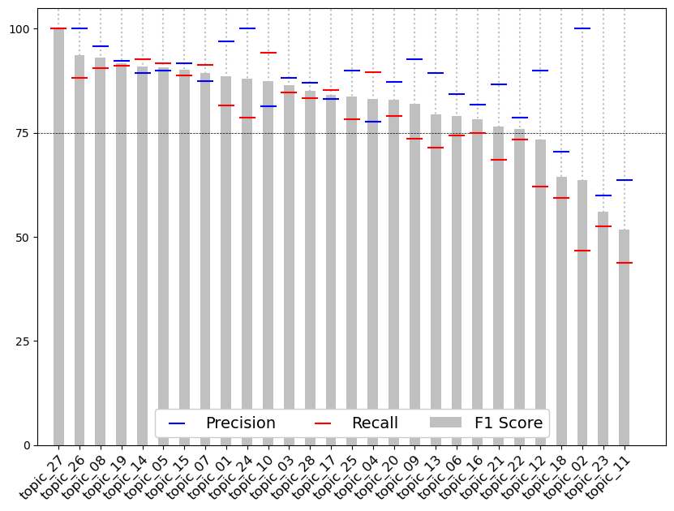

```
Precision to Topic Occurence Correlation: -0.02
Recall to Topic Occurence Correlation: 0.43
F1 Score to Topic Occurence Correlation: 0.31
```

```python
# Examine performance metrics on a topic level

# Get prediction outcomes and calculation metrics for each topic
precision_list = []
recall_list = []
f1_list = []
for topic in range(len(distinct_topics)):
    t_tp = sum((results_df["test_encoded"].apply(lambda x: x[topic] == 1)) &
               (results_df["predicted_encoded"].apply(lambda x: x[topic] == 1)))

    t_tn = sum((results_df["test_encoded"].apply(lambda x: x[topic] == 0)) &
               (results_df["predicted_encoded"].apply(lambda x: x[topic] == 0)))

    t_fp = sum((results_df["test_encoded"].apply(lambda x: x[topic] == 0)) &
               (results_df["predicted_encoded"].apply(lambda x: x[topic] == 1)))

    t_fn = sum((results_df["test_encoded"].apply(lambda x: x[topic] == 1)) &
               (results_df["predicted_encoded"].apply(lambda x: x[topic] == 0)))

    t_precision = round((t_tp / (t_tp + t_fp)) * 100, 2)
    t_recall = round((t_tp / (t_tp + t_fn)) * 100, 2)
    t_f1 = round(2 * ((t_precision * t_recall) / (t_precision + t_recall)), 2)

    precision_list.append(t_precision)
    recall_list.append(t_recall)
    f1_list.append(t_f1)

# Calculate correlation between topic occurence counts and performance metrics
occurence_list = topic_value_counts.sort_index()
precision_corr = np.corrcoef(occurence_list, precision_list)
recall_corr = np.corrcoef(occurence_list, recall_list)
f1_corr = np.corrcoef(occurence_list, f1_list)

# Sort lists on F1 score
combined_lists = sorted(zip(f1_list, precision_list, recall_list, distinct_topics), reverse=True)
f1_list, precision_list, recall_list, topic_list = zip(*combined_lists)

# Plot bar and scatter plot of topic performance metrics
fig, ax = plt.subplots(figsize=(10, 7))
ax.scatter(np.arange(len(distinct_topics)), precision_list, s=200, c="blue", marker="_", label="Precision", zorder=3)
ax.scatter(np.arange(len(distinct_topics)), recall_list, s=200, c="red", marker="_", label="Recall", zorder=3)
plt.bar(np.arange(len(distinct_topics)), f1_list, width=0.5, label="F1 Score", color="silver", zorder=1)

# X-ticks
ax.set_xticks(np.arange(len(distinct_topics)))
ax.set_xticklabels(topic_list, fontsize=12, rotation=45, ha="right", rotation_mode="anchor")
ax.hlines(y = 75, xmin = -1, xmax = len(distinct_topics) + 1, colors="black", linestyle="dashed", linewidth=0.5, zorder=2)
ax.set_xlim(-1, len(distinct_topics) + 1)

# Y-ticks
ax.set_yticks(np.arange(0, 101, 25))
ax.set_yticklabels(np.arange(0, 101, 25))
ax.vlines(x = np.arange(len(distinct_topics)), ymin = 0, ymax = 105, colors="silver", linestyle="dotted", zorder=0)
ax.set_ylim(0, 105)

# Legend
ax.legend(loc="lower center", fontsize=14, ncol=3, framealpha=1)

plt.show()

# Print correlation between topic occurence counts and performance metrics
print(f"Precision to Topic Occurence Correlation: {round(precision_corr[0, 1], 2)}")
print(f"Recall to Topic Occurence Correlation: {round(recall_corr[0, 1], 2)}")
print(f"F1 Score to Topic Occurence Correlation: {round(f1_corr[0, 1], 2)}")
```

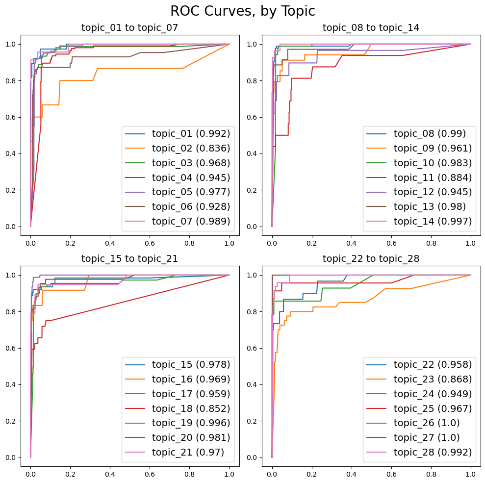

```python
# Plot ROC curves on a topic level

# Initialize lists for storing results
fpr_list = []
tpr_list = []
auc_list = []
for topic in range(len(distinct_topics)):

    # Isolate prediction for current topic only
    topic_actual = [element[topic] for element in list(y_test)]
    topic_probs = [element[topic] for element in norm_preds]

    # Calculate false positive and true positive rates, and auc scores
    fpr, tpr, thresholds = roc_curve(topic_actual, topic_probs)
    auc = roc_auc_score(topic_actual, topic_probs)

    # Append to lists for plotting
    fpr_list.append(fpr)
    tpr_list.append(tpr)
    auc_list.append(auc)

# ROC curves across 4 graphs
fig, axs = plt.subplots(2, 2, figsize=(10, 10), edgecolor="white") # Create figure and subplots
fig.suptitle("ROC Curves, by Topic", fontsize=20) # Set the title of the figure

# Iterate over each subplot index
for i in range(4):
    # Calculate the row and column index of the current subplot, and first and last topic in subset
    row = i // 2
    column = i % 2
    first_topic = i * 7
    last_topic = (i + 1) * 7

    # Create subplot title
    axs[row, column].set_title(f"{distinct_topics[first_topic]} to {distinct_topics[last_topic - 1]}", fontsize=14)

    # For each topic in subset
    for topic in range(first_topic, last_topic):
        label = f"{distinct_topics[topic]} ({round(auc_list[topic], 3)})"
        axs[row, column].plot(fpr_list[topic], tpr_list[topic], label=label)
    axs[row, column].legend(loc="lower right", fontsize=14)

plt.tight_layout()
plt.show()
```

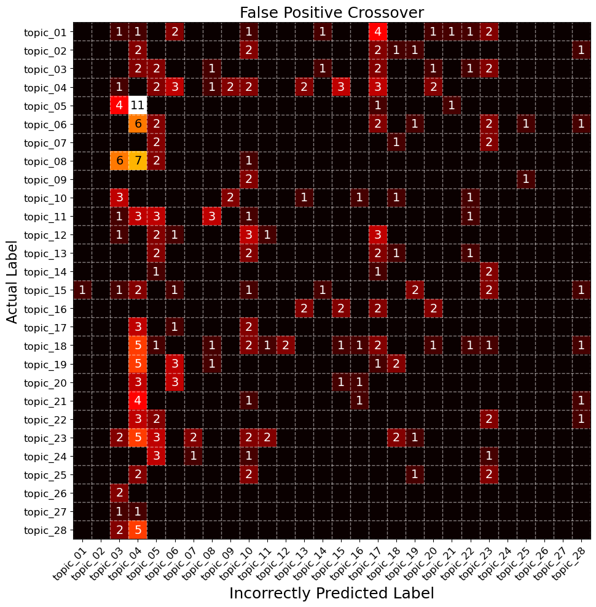

```python
# Plot heatmap of false positive crossover

# Create nested list of false positive crossover for plotting
plot_list = []
highest = 0
for topic in range(len(distinct_topics)):
    sub_list = []
    for sub_topic in range(len(distinct_topics)):

        error_count = sum((results_df["test_encoded"].apply(lambda x: x[topic] == 1)) &
                          (results_df["test_encoded"].apply(lambda x: x[sub_topic] == 0)) &
                          (results_df["predicted_encoded"].apply(lambda x: x[sub_topic] == 1)))
        highest = max(highest, error_count)
        sub_list.append(error_count)
    plot_list.append(sub_list)

# Plot heatmap
fig, ax = plt.subplots(figsize=(10, 10))
im = ax.imshow(plot_list, cmap="hot")

# Set title
ax.set_title("False Positive Crossover", fontsize=18)

# X-ticks and label
plt.xlabel("Incorrectly Predicted Label", fontsize=18)
ax.set_xticks(np.arange(len(distinct_topics)))
ax.set_xticklabels(distinct_topics, fontsize=12, rotation=45, ha="right", rotation_mode="anchor")
ax.xaxis.set_minor_locator(MultipleLocator(0.5))

# Y-ticks and label
plt.ylabel("Actual Label", fontsize=16)
ax.set_yticks(np.arange(len(distinct_topics)))
ax.set_yticklabels(distinct_topics, fontsize=12)
ax.yaxis.set_minor_locator(MultipleLocator(0.5))

# Add grid
ax.grid(which="minor", color="w", linestyle="dashed", linewidth=1, alpha=0.5)
ax.tick_params(which='minor', size=0)

# Add value labels, with colours based on cell colour for contrast
for i in range(len(distinct_topics)):
    for j in range(len(distinct_topics)):
        count = plot_list[i][j]
        c = "black" if count > (highest / 2) else "white"
        if count > 0:
            text = ax.text(j, i, count, ha="center", va="center", color=c, fontsize=14)

# Show plot
fig.tight_layout()
plt.show()
```

### Explainability Analysis

Explainability analysis is conducted to gain insights into the inner workings of the trained model and attempt explain the rationale behind its predictions. However, it should be noted that interpretability techniques performed on neural networks do have limitations, including providing localized-only explanations, and lacking global understanding and contextual comprehension. As such, their results cannot be taken as definitive explanations of the exact inner-workings behind the model's decision-making and should be considered as complementary tools only.

Two key techniques are employed for this analysis:

- **Shapley Additive Explanations (SHAP)**  
  SHAP is framework for interpreting machine learning models, such as the one used in this project. It provides a way to understand the contribution of each feature (in this case TF-IDF features) to a model's predictions. The core idea behind SHAP is derived from cooperative game theory and the concept of Shapley values, which assign a fair distribution of a value among contributors. It works by:
  1. Baseline Prediction: A baseline prediction is established, using the average prediction of the model as a reference point. This serves as a starting point for attributing contributions.
  2. Feature Permutations: For each feature, the contribution of that feature is calculated by considering its absence (i.e., setting it to the baseline value) and its presence (i.e., keeping it at its actual value) in the prediction. This involves creating permutations of feature values, with some features fixed at their baseline values while others vary.
  3. Model Predictions: For each permutation of feature values, the model predicts the outcome. The difference between the model's prediction with the feature and without the feature represents the impact of that feature.
  4. Shapley Value Calculation: The Shapley value for a particular feature is calculated by averaging the differences in model predictions across all possible permutations. This accounts for all possible combinations of feature contributions and ensures that each feature is fairly rewarded for its contribution. SHAP values have an additive property, meaning that the sum of SHAP values for all features plus the baseline prediction equals the actual prediction. This ensures that the interpretation of the prediction is consistent and mathematically coherent. SHAP values also satisfy two important properties: consistency and local accuracy. Consistency ensures that if a feature's value increases, its corresponding SHAP value does not decrease. Local accuracy ensures that the sum of SHAP values equals the difference between the model's prediction for the instance and the expected baseline prediction.
- **Local Interpretable Model-agnostic Explanations (LIME)**  
  LIME is a technique used to explain the predictions of a model by providing human-interpretable explanations. It works by:  
  Selecting an Instance: You start by selecting a specific document (instance) for which you want an explanation. This document might have been classified by the model, and you're interested in understanding why it received that specific classification.
  1. Perturbing the Document: LIME generates an interpretable explanation by perturbing or modifying the a given TF-IDF matrix. It creates a new dataset with instances that are similar to the original TF-IDF matrix but have slight modifications.
  2. Generating a Sample: LIME then samples instances from this perturbed dataset. Each of these instances represents a slight variation of the original TF-IDF matrix. These samples are used to train an interpretable explanation model.
  3. Learning an Explanation Model: LIME selects a simple, interpretable model (like a linear regression or decision tree) that can approximate the behavior of the complex classifier in the local vicinity of the selected document.
  4. Mapping Predictions: The explanation model is trained to map the perturbed instances to the predictions of the complex classifier. It learns how changes in the TF-IDF matrix features affect the model's output.
  5. Generating Feature Importance: Once the explanation model is trained, LIME quantifies the importance of each feature in the original TF-IDF matrix by analyzing the coefficients of the explanation model. These coefficients indicate how much each feature contributes to the prediction. The explanation provided by LIME is specific to the selected email. It helps you understand why the model made the particular prediction for that instance. It doesn't attempt to provide a global view of the model's behavior, but rather focuses on a local context.

### SHAP

The results of the SHAP analysis are displayed in 2 visualizations:

1. A line chart plotting the TF-IDF features and their absolute value SHAP values, arranged in descending order.  
   It illustrates a dramatic drop in predictive power outside of the 500 or so most influential tokens, and that outside the 1500 or so most influential, the predictive power of the included tokens is near zero. This suggests that future iterations might be able to use a smaller corpus of tokens, improving computational performance without sacrificing predictive power.
2. For each topic, a scatter plot showing the SHAP values across each of the emails in the testing set of the top 10 most influential TF-IDF features (in terms of their absolute value SHAP values).  
   While they have been redacted, it illustrates for each topic what TF-IDF features have the most impact, either positive or negative, on the model predicting that topic. It shows that the general impact of influential features on topics can differ quite significantly:
   - For some, such as topic_01 and topic_06, a few of the features tend to have a positive impact on that topic being predicted and none tend to have a negative impact on that topic being predicted.
   - For others, such as topic_12 and topic_13, a few of the features tend to have a negative impact on that topic being predicted and none tend to have a postive impact on that topic being predicted.
   - For others still, such as topic_02, a few of the features tend to have a positive impact on that topic being predicted and a few tend to have a negative impact on that topic being predicted.
   - For the rest, the features tend to have a positive impact in some emails and a negative impact in others.

```python
# SHAP
shap_explainer = shap.Explainer(model, X_test, feature_dependence="independent")
shap_values = shap_explainer.shap_values(X_test)

sum_array = np.full(shap_values[0].shape, 0.0)
for i in range(shap_values.shape[0]):
    sum_array += shap_values[i]
sum_array = sum_array / np.full(sum_array.shape, float(shap_values.shape[0]))

shap_df = pd.DataFrame(sum_array, columns=distinct_topics)
shap_df["average_abs_shap"] = shap_df.abs().mean(axis=1)
shap_df.insert(0, "token", tfidf_vectorizer.get_feature_names_out())

redact_dataframe(shap_df.sort_values(by="average_abs_shap", ascending=False), ["token"]).head(5)
```

|  | token | topic_01 | topic_02 | topic_03 | topic_04 | topic_05 | topic_06 | topic_07 | topic_08 | topic_09 | ... | topic_20 | topic_21 | topic_22 | topic_23 | topic_24 | topic_25 | topic_26 | topic_27 | topic_28 | average_abs_shap |
| --- | --- | --- | --- | --- | --- | --- | --- | --- | --- | --- | --- | --- | --- | --- | --- | --- | --- | --- | --- | --- | --- |
| 2553 | xxxxxxxx | -3.494859e-07 | 0.000005 | 0.000145 | -0.002115 | 0.000266 | -0.000056 | 0.000058 | 0.000170 | 0.000010 | ... | -0.000002 | 0.000002 | 0.000048 | 0.000037 | 0.000004 | 0.000047 | 0.000057 | 4.159288e-07 | 0.000141 | 0.000155 |
| 816 | xxxxxxxx | -2.987743e-06 | -0.000060 | 0.001227 | -0.000306 | -0.000225 | 0.000016 | 0.000253 | -0.000137 | 0.000148 | ... | 0.000090 | 0.000004 | -0.000007 | 0.000083 | -0.000022 | 0.000056 | -0.000240 | -6.095486e-05 | -0.000199 | 0.000142 |
| 391 | xxxx | -1.554998e-03 | 0.000008 | 0.000108 | -0.000167 | 0.000369 | 0.000061 | 0.000136 | 0.000477 | -0.000026 | ... | 0.000029 | -0.000016 | 0.000030 | 0.000233 | -0.000002 | 0.000011 | -0.000005 | 7.970332e-06 | 0.000025 | 0.000130 |
| 1060 | xxxxxxxx | -5.139574e-05 | -0.000008 | -0.000286 | -0.000222 | 0.000037 | -0.000057 | 0.000102 | -0.000161 | -0.000023 | ... | 0.000019 | -0.000009 | -0.000148 | -0.000109 | -0.000021 | -0.000159 | -0.000016 | -1.140964e-05 | -0.000039 | 0.000118 |
| 3546 | xxxxxxx | -5.578543e-05 | -0.000014 | 0.000158 | -0.000133 | -0.000490 | -0.000302 | 0.000013 | 0.000577 | -0.000082 | ... | -0.000010 | -0.000034 | 0.000039 | 0.000360 | -0.000009 | 0.000055 | -0.000006 | -4.561625e-05 | 0.000004 | 0.000099 |

5 rows × 30 columns

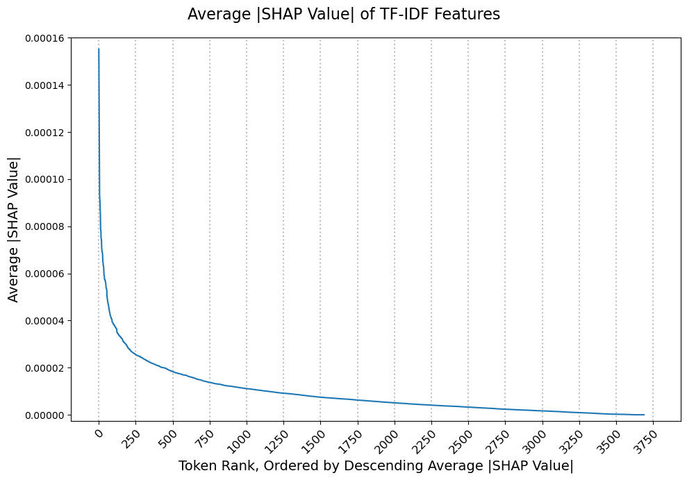

```python
# Plot Average |SHAP Value| of TF-IDF Features
fig, ax = plt.subplots(figsize=(10, 7))

fig.suptitle("Average |SHAP Value| of TF-IDF Features", fontsize=16)

plot_df = shap_df.sort_values(by="average_abs_shap", ascending=False)
ax.plot(plot_df["token"], plot_df["average_abs_shap"])

ax.set_xlabel("Token Rank, Ordered by Descending Average |SHAP Value|", fontsize=14)
x_ticks = np.arange(0, np.ceil(plot_df.shape[0] / 250 + 1) * 250, 250).astype(int)
ax.set_xticks(x_ticks)
ax.set_xticklabels(x_ticks, fontsize=12, rotation=45, ha="right", rotation_mode="anchor")

ylim = (-0.0000025, round(max(plot_df["average_abs_shap"]), 5))
ax.set_ylim(ylim)
ax.vlines(x = x_ticks, ymin = ylim[0], ymax = ylim[1], colors="silver", linestyle="dotted", zorder=0)

ax.set_ylabel("Average |SHAP Value|", fontsize=14)

# Show plot
fig.tight_layout()
plt.show()
```

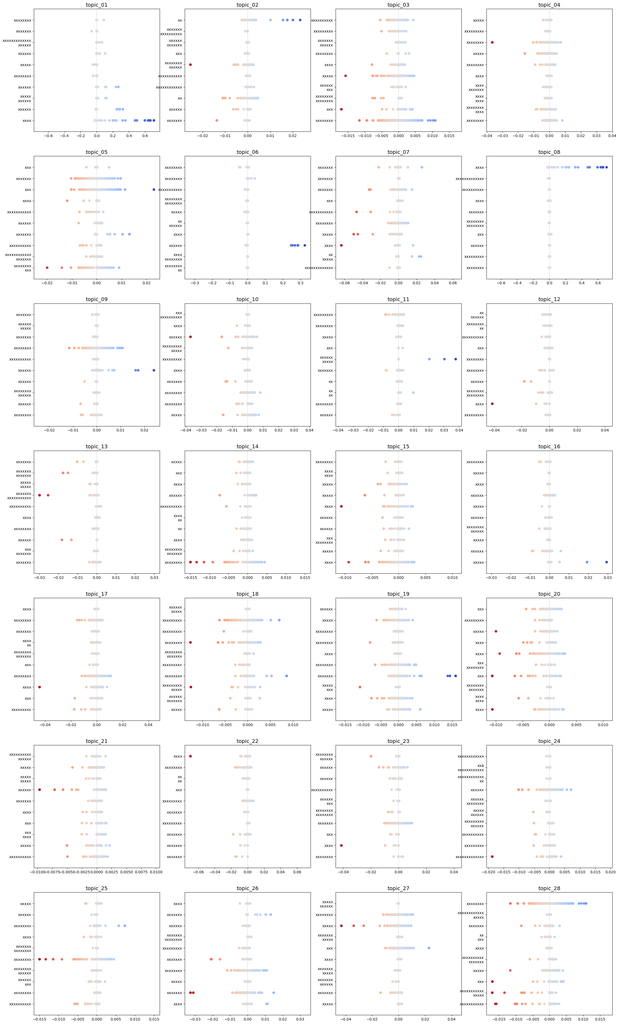

```python
# Plot top 10 influential tokens per topic
columns = 4
rows = int(np.ceil(len(distinct_topics) / columns))
fig, axs = plt.subplots(rows, columns, figsize=(columns * 7, rows * 7), edgecolor="white")

# Iterate over each subplot index
include_top_n_values = 10
for i in range(rows * columns):
    # Calculate the row and column index of the current subplot
    row = i // columns
    column = i % columns

    plot_df = shap_df.iloc[shap_df[distinct_topics[i]].abs().argsort()[::-1]].head(include_top_n_values)
    plot_list = []
    for index in plot_df.index:
        sub_list = []
        for shap_array in shap_values:
            sub_list.append(shap_array[index, 0])
        plot_list.append(sub_list)

    num_tokens = len(plot_list)
    num_samples = len(plot_list[0])
    y_values = [[i] * num_samples for i in range(num_tokens)]
    max_value = max(np.abs(np.array(plot_list)).flatten())
    norm = plt.Normalize(-max_value, max_value)

    axs[row, column].set_title(distinct_topics[i], fontsize=14)
    axs[row, column].scatter(plot_list, y_values, c=plot_list, cmap="coolwarm_r", norm=norm)

    axs[row, column].set_yticks(np.arange(num_tokens))
    token_list = [token.replace(" ", "\n") for token in redact_dataframe(plot_df, ["token"])["token"]]
    axs[row, column].set_yticklabels(token_list, fontsize=10)

    axs[row, column].set_xlim(max_value * -1.1, max_value * 1.1)
    axs[row, column].set_ylim(-1, num_tokens)
    axs[row, column].vlines(x = 0, ymin = -1, ymax = num_tokens, colors="silver", linestyle="dotted", zorder=0)
```

### Lime

The results of the LIME analysis are displayed in the following visualisation:

1. For a given email, normalized probabilities of each topic are plotted as are the top 10 most influential tokens in terms of LIME.  
   This gives insight on a local-level into why the model reached a particular decision for on an individual email level, and illustrates in local context which tokens had a positive and negative impact on the model's decision making.

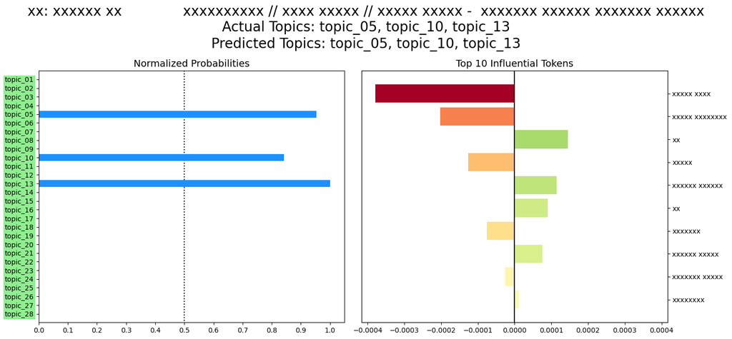

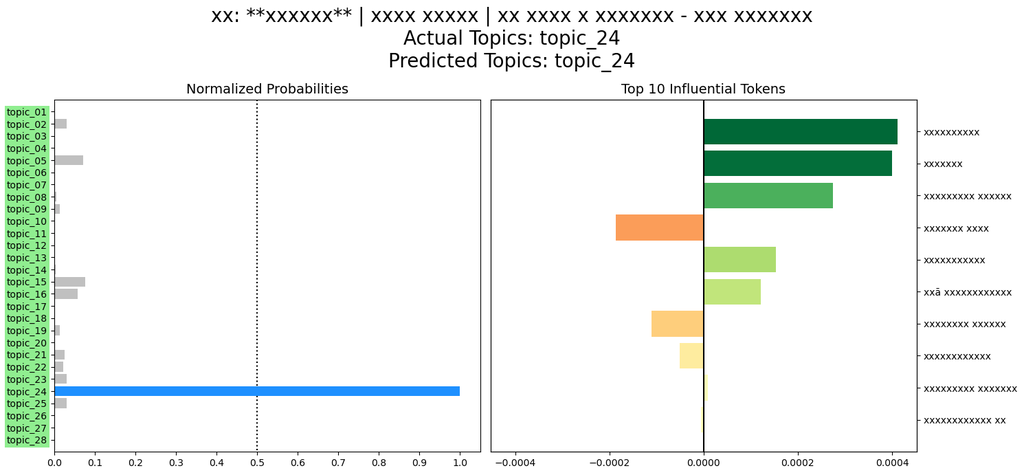

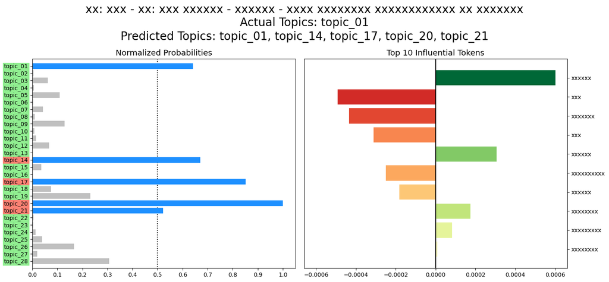

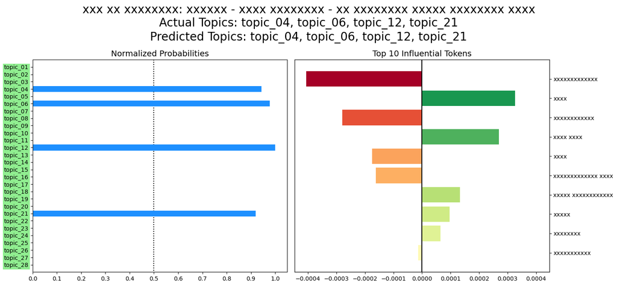

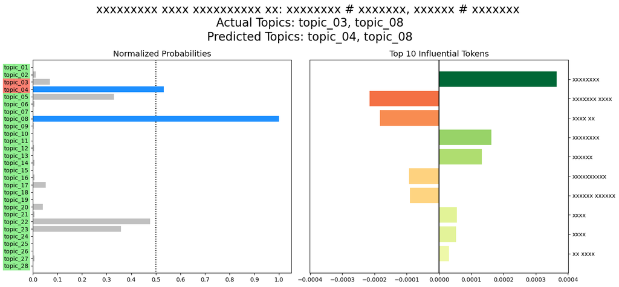

```python
# LIME
lime_explainer = LimeTabularExplainer(training_data=tfidf_matrix,
                                      feature_names=tfidf_vectorizer.get_feature_names_out(),
                                      class_names=distinct_topics,
                                      discretize_continuous=True)

def predict_fn(matrix):
    probs = model.predict(matrix)
    return probs

for i in [random.randint(0, X_test.shape[0]) for n in range(5)]:
    i_norm_preds = norm_preds[i]
    i_actual = y_test[i]
    i_actual_eng = actual_english[i]
    i_predicted_eng = predicted_english[i]
    i_subject = re.sub('[a-zA-Z0-9]', 'x', subjects_test[i])

    exp = lime_explainer.explain_instance(X_test[i], predict_fn, num_features=10, num_samples=5000)
    tokens_and_weights = exp.as_list()
    tokens = [tup[0] for tup in tokens_and_weights]
    weights = [tup[1] for tup in tokens_and_weights]
    max_abs_weight = max(np.abs(weights))

    # Plot
    fig, (ax1, ax2) = plt.subplots(1, 2, figsize=(15, 7), edgecolor="white")
    title = f"{i_subject}\nActual Topics: {i_actual_eng}\nPredicted Topics: {i_predicted_eng}"
    fig.suptitle(title, fontsize=20)

    # Axis 1
    ax1.set_title("Normalized Probabilities", fontsize=14)

    colours = ["dodgerblue" if element >= 0.5 else "silver" for element in i_norm_preds]
    ax1.barh(distinct_topics, i_norm_preds, color=colours)

    ax1.set_xlim(0, 1.05)
    ax1.set_xticks(np.arange(0, 1.01, 0.1))

    ax1.set_ylim(len(distinct_topics), -1)
    ax1.vlines(x = 0.5, ymin = -1, ymax = len(distinct_topics), colors="black", linestyle="dotted", zorder=0)

    for i, label in enumerate(ax1.get_yticklabels()):
        highlight_colour = "lightgreen" if round(i_norm_preds[i]) == i_actual[i] else "salmon"
        label.set_bbox({"facecolor": highlight_colour, "edgecolor": "none", "pad": 2})

    # Axis 2
    ax2.set_title(f"Top {len(tokens)} Influential Tokens", fontsize=14)

    norm = Normalize(vmin=max_abs_weight*-1, vmax=max_abs_weight)
    colours = plt.cm.RdYlGn(norm(weights))
    ax2.barh(tokens, weights, color=colours)

    ax2.set_xlim(max_abs_weight * -1.1, max_abs_weight * 1.1)

#     ax2.set_ylim(-1, len(tokens_and_weights))
    ax2.set_ylim(len(tokens_and_weights), -1)
    ax2.vlines(x = 0, ymin = -1, ymax = len(tokens_and_weights), colors="black", zorder=1)

    ax2.yaxis.set_visible(False)
    ax_right = ax2.twinx()
    ax_right.set_ylim(ax2.get_ylim())
    ax_right.set_yticks(np.arange(len(tokens)))
    ax_right.set_yticklabels([re.sub("[a-zA-Z0-9]", "x", token) for token in tokens])

    plt.tight_layout()
    plt.show()
```

### Conclusion

In conclusion, the project aimed to develop a data science solution using a Natural-Language-Processing neural network to identify what topic(s) a given email is about. The motivation stems from the need of a business unit operating from a shared Outlook inbox to gain a clear understanding of their email communication, allowing them to improve planning, resource allocation, and delivering training for other business units. Given that the emails could pertain to any number of different topics, the model must be able to identify multiple, non-mutally-exclusive topics.

The trained model showed promising results in labelling emails, achieving a high F1 Score of 85.22%. There was significant variation in performance across different topics, and opportunities for potential improvement in future iterations of the project were identified:

- Merging topics that high rates of co-occurence
- Utilising a smaller corpus of tokens in the TF-IDF matrix

Overall, the data science solution utilizing Natural-Language-Processing proved valuable in labelling emails and provide immediate benefit to the business unit in question.